# P-value project

28.03.2018

## Data

- Number of persons interviewed: 172
- Proportion of females: 0.56
- Average proportion of correct answers: 0.67

## Statistical experience

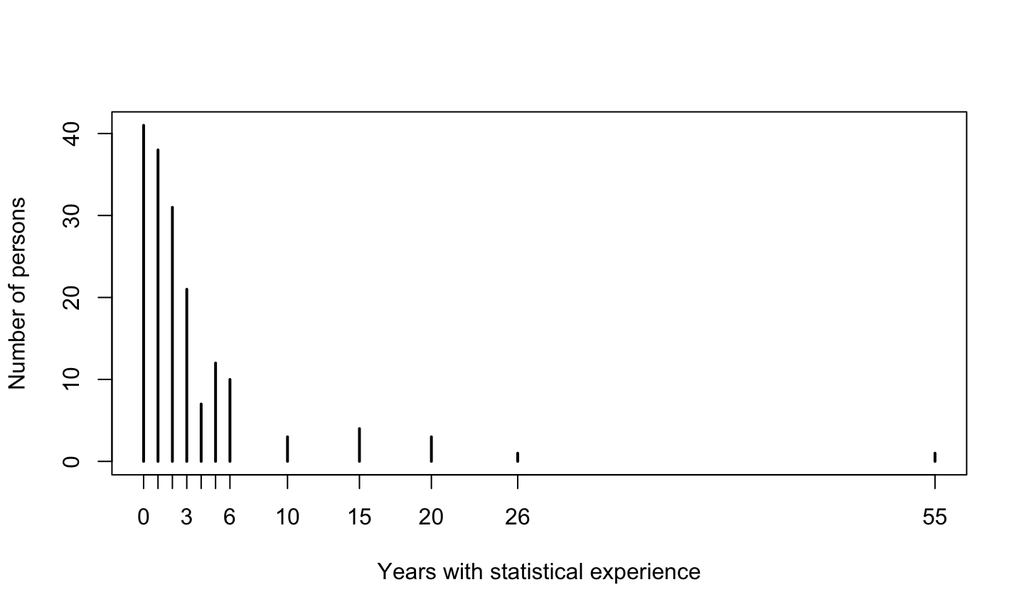

## Statistical methods

- Logistic regression (outcome 0 or 1)
- Person ID as random effect to account for repeated measurements (each person gave 10 answers)
- Experimental treatment: figures with or without p-value
- Covariate: statistical experience of person (in log(years+1))
- Interaction treatment x experience

## Main result

|  | Estimate | Std. Error | P-Value |
| --- | --- | --- | --- |
| Intercept | 0.118 | 0.274 | 0.668 |
| Statistical experience [log(year+1)] | 1.244 | 0.237 | 0.000 |
| Treatment | 0.341 | 0.382 | 0.372 |
| Treatment x Experience | -0.955 | 0.314 | 0.002 |

## Experienced persons excluded

|  | Estimate | Std. Error | P-Value |
| --- | --- | --- | --- |
| Intercept | 0.018 | 0.294 | 0.952 |
| Statistical experience [log(year+1)] | 1.437 | 0.300 | 0.000 |
| Treatment | 0.291 | 0.418 | 0.485 |
| Treatment x Experience | -0.971 | 0.404 | 0.016 |

- Persons with more more than 9 years of statistical experience excluded.
- Results remain remarkably stable.

## Deceived by p-values

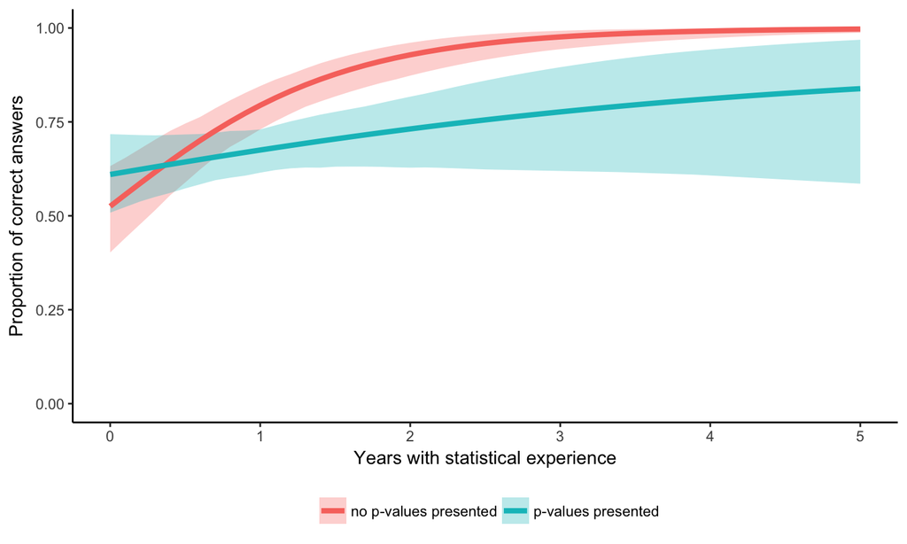

Correct answers increased with statistical experience, but less so when p-values were presented. Given are model predictions (lines) and 95% credible intervals (shaded areas).

## What affects the answers?

- Only data from figures that shows confidence intervals AND p-values
- Logistic regression
- Outcome variable: 1 if person say left figure is correct, 0 otherwise.
- First predictor: difference in confidence interval length
- Second predictor: difference in p-values
- Person ID as random effect to account for repeated measurements (each person gave 5 answers)

## What affects the answers?

If figures with confidence intervals and p-values are presented, the answers are more strongly guided by the difference in p-value than the differences in confidence interval length.

|  | Estimate | Std. Error | P-Value |
| --- | --- | --- | --- |
| Intercept | -0.154 | 0.114 | 0.177 |
| Delta conf. intervals | 0.907 | 0.143 | 0.000 |
| Delta p-values | 1.564 | 0.392 | 0.000 |

## Boxplots vs. confidence intervals?

- Only data from figures that do NOT show p-values
- Logistic regression
- Outcome variable: 1 answer is correct, 0 answer is not correct
- Predictor: 1 Figure shows a box-plot, 0 otherwise.
- Person ID as random effect to account for repeated measurements (each person gave 5 answers)

## Boxplots vs. confidence intervals?

|  | Estimate | Std. Error | P-Value |
| --- | --- | --- | --- |
| Intercept | 1.711 | 0.316 | 0.000 |
| Boxplot | -0.174 | 0.197 | 0.377 |

The proportion of correct answers was slightly higher for figures with confidence intervals (0.85) than for figures with box-plots (0.82). But the difference was not significant.

## Effect of observer and gender

|  | Estimate | Std. Error | P-Value |
| --- | --- | --- | --- |
| Intercept | 0.268 | 0.321 | 0.403 |
| Statistical experience [log(year+1)] | 1.247 | 0.238 | 0.000 |
| Treatment | 0.341 | 0.381 | 0.372 |
| Observer | -0.113 | 0.243 | 0.643 |
| Gender | -0.203 | 0.246 | 0.409 |
| Treatment x Experience | -0.971 | 0.314 | 0.002 |